# ML HW1

### Minibatch Gradient Descent

#### Result

```
learning rate: 0.001, batch size: 10, number of iterations: 50
```

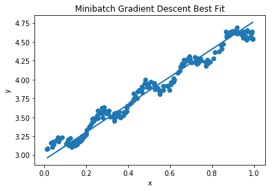

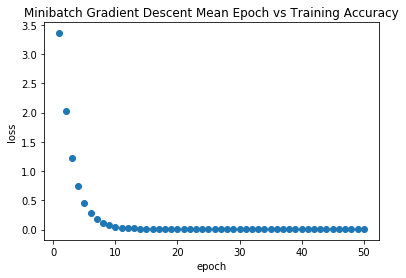

```
learning rate: 0.001, batch size: 50, number of iterations: 50
```

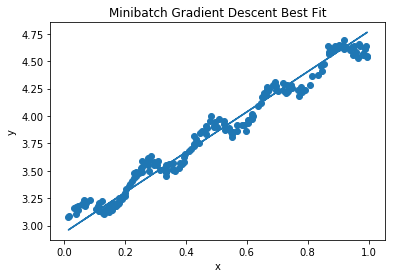

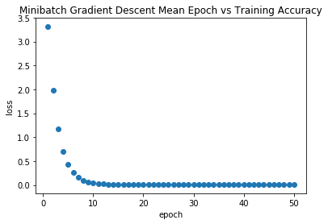

```
learning rate: 0.001, batch size: 100, number of iterations: 50
```

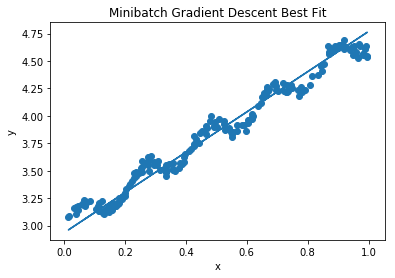

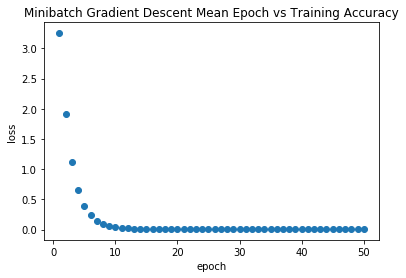

```
learning rate: 0.005, batch size: 10, number of iterations: 50
```

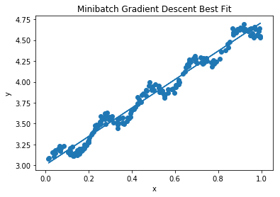

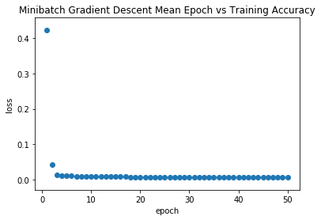

```
learning rate: 0.005, batch size: 50, number of iterations: 50
```

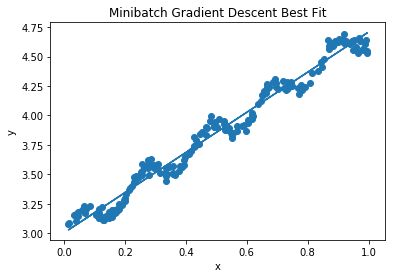

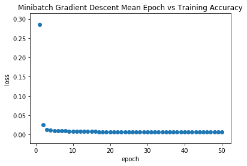

```
learning rate: 0.005, batch size: 100, number of iterations: 50
```

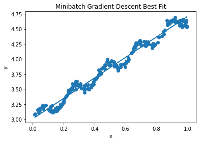

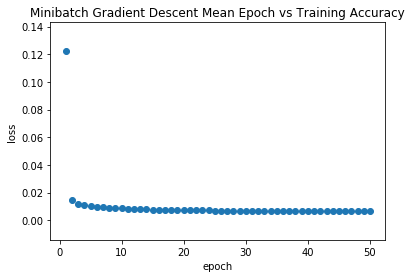

```
learning rate: 0.01, batch size: 10, number of iterations: 50
```

[24 more figures not shown]

```python
learning_rate_list = [0.001, 0.005, 0.01, 0.05, 0.1, 0.3]
for learning_rate in learning_rate_list:
    for batch_size in [10, 50, 100]:
        print('learning rate: {}, batch size: {}, number of iterations: 50'.format(learning_rate, batch_size))
        thetas = minibatch_gradient_descent(x, y, learning_rate, 50, batch_size)
        plot(x, y, thetas[-1], "Minibatch Gradient Descent Best Fit")
        # print(thetas)
        plot_training_errors(
            x, y, thetas, "Minibatch Gradient Descent Mean Epoch vs Training Accuracy")
```

#### Observation

From observing the results above, we can see when the batch size is larger, we need to tone down the learning rate in order to avoid the diverging.

## 3 Sample Exam Questions:

### 3.1

The MSE will be 0 as every point in the data set sits perfectly on the same line, so we can use linear regression to find a line to fit the data set perfectly.

### 3.2

#### (a)

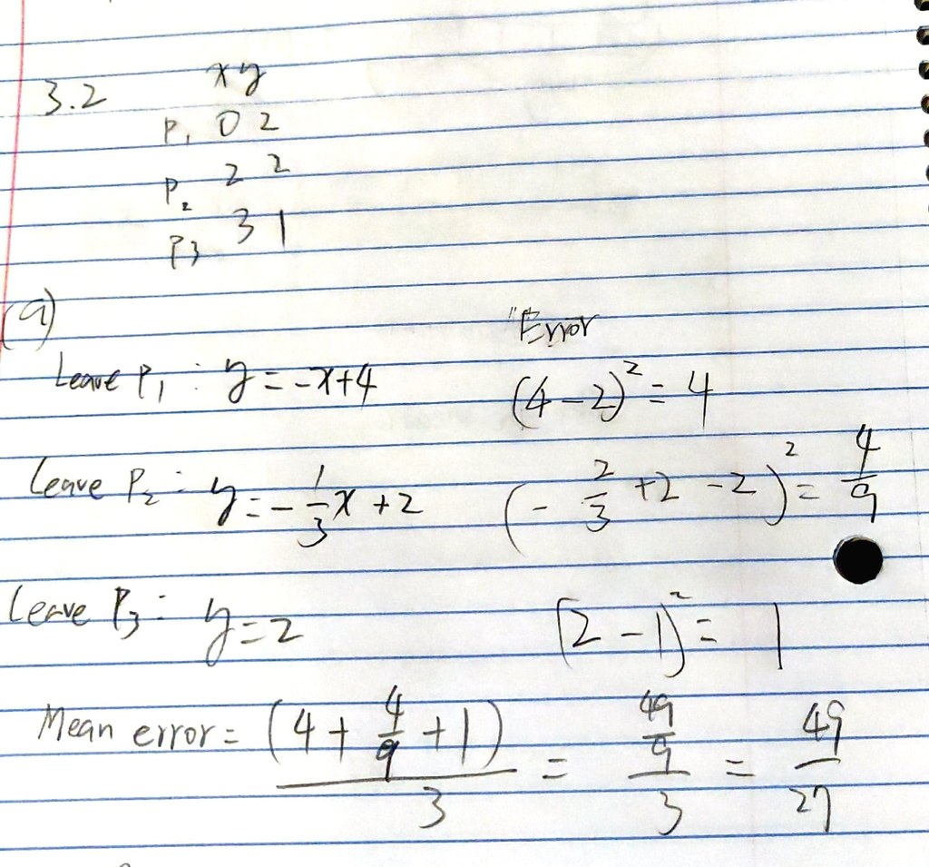

#### (b)

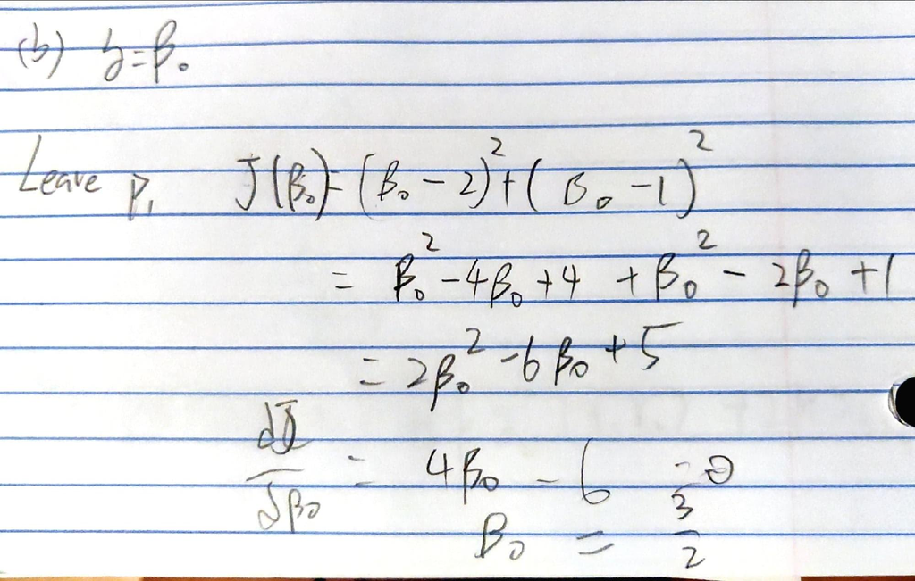

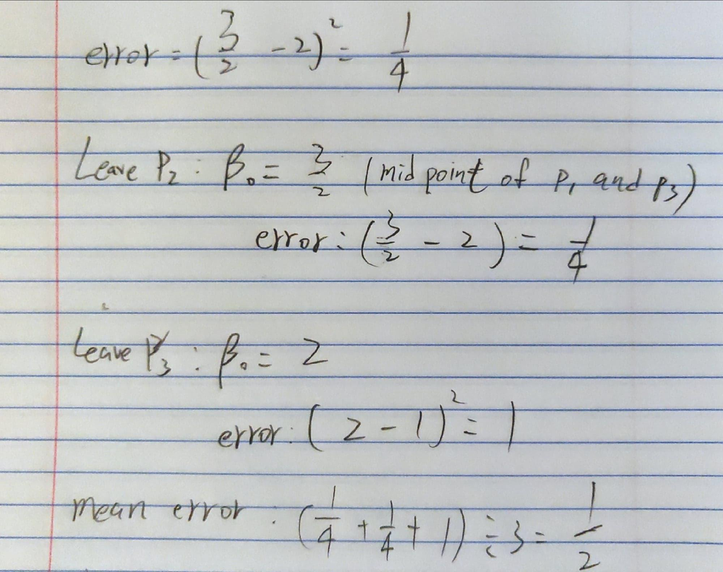

(c) The second model, since it produced a smaller error

### 3.3

(e) A, because the smaller the training data set is, the easier it is for us to find a line that fits the data points. Two points, for example, can be perfectly fit with 0 training error.

(f) B, because as we increase the size of the training data set, the model should generalize better and be able to make better predictions on the testing data.